# Variable Selection in Function-on-Scalar Regression

Yakuan Chen and Jeff Goldsmith

2015-05-07

This guide illustrates the use of `fosr.vs()` to conduct variable selection in the context of linear function-on-scalar regression models. We compare the results to two other methods for function-on-scalar regression without variable selection.

## Simulated data

We simulate 100 functional responses with correlated errors according to the linear function-on-scalar regression model. Three non-zero coefficient functions are used (a constant intercept, a sine curve, and a cosine curve) together with 17 zero coefficient functions; scalar predictors are generated from a standard normal distribution. Correlated errors are introduced using functional principal components with two basis functions (a sine and cosine of periods different than the coefficient functions) and subject-specific loadings are generated from mean-zero normal distributions with variance 3 and 1. Finally, uncorrelated measurement error is added to all curve. The figure below shows this observed data.

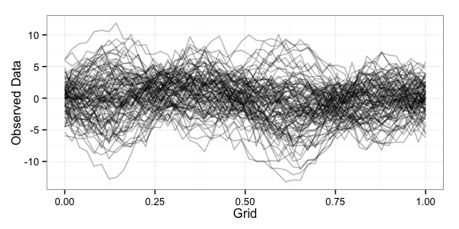

## Model Fitting

There are several tools for fitting the function-on-scalar regression model. We first fit this model using `fosr.vs` to conduct variable selection. Other options are `refund::pffr()` and `BayesFoSR::bayes_fosr()`, which do not induce sparsity and are used as a point of reference. All methods are used below.

```r
fit.fosr.vs = fosr.vs(Y~0+X, data = data, method="grMCP")
```

```
## Beginning iterative algorithm
## .
```

```r
fit.vb = bayes_fosr(Y~0+X, data = data, Kt = 10, est.method = "VB", cov.method = "FPCA")

Y = data$Y
for(i in 1:20){
  assign(paste0("x", i), data[,i])
}
fit.pffr = pffr(Y ~ 0 + x1 + x2 + x3 + x4 + x5 + x6 + x7+ x8 + x9 + x10 +
         x11 + x12 + x13 + x14 + x15 + x16 + x17+ x18 + x19 + x20,
         bs.yindex = list(bs = "ps", k = 10, m = c(2, 1)))
```

## Model comparisons

Below we plot the estimates of nonzero coefficient functions from each of the methods. Methods are broadly similar in estimating these non-zero coefficient functions, although estimates from `fosr.vs()` are not affected by the estimation of zero coefficients.

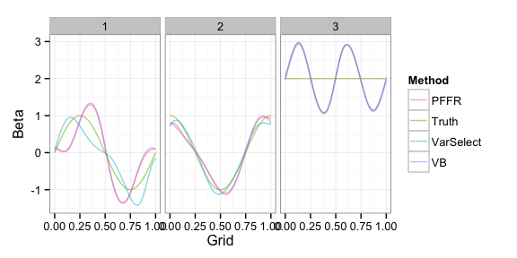

Next we plot the estimates of zero coefficient functions. In this example `fosr.vs()` correctly estimates all zero coefficients as zero, while `pffr()` and `bayes_fosr()` often estimate coefficients that are very different from zero.

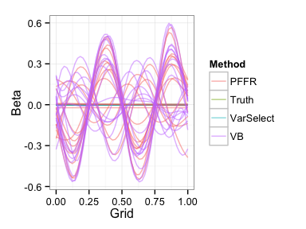